# ACP_reg corrigé

Aurélien Nicosia

31 aout 2023

## Régression avec ACP

On a parlé de l’utilité de l’ACP pour réduire la dimensionalité et du fait qu’on pourrait ainsi l’utiliser dans un modèle prédictif.  
Voyons un petit exemple ici.

### Les données

```r
library(ISLR)
data(Hitters)
dim(Hitters)
```

```
## [1] 322  20
```

```r
hitters2 = Hitters[complete.cases(Hitters),-c(14,15,20)]

#set.seed(134) #Pour que les résultats soient reproductibles
#val.index = sample(1:263, 50)
val.index = c(170, 83, 38, 234, 189, 159, 197, 152, 68, 256, 39, 150, 219,
187, 239, 220, 212, 113, 172, 198, 177, 174, 211, 164, 225, 208,
213, 42, 46, 70, 120, 168, 86, 20, 184, 91, 261, 154, 134, 161,
11, 81, 149, 153, 214, 18, 115, 140, 217, 5)
dat.train = hitters2[-val.index,]
dat.test = hitters2[val.index,]
```

### Régression linéaire

On commence par ajuster une régresion linéaire avec les variables originales du jeu de données. En utilisant ce modèle, calculez l’écart quadratique moyen de vos prévisions dans le jeu d’entrainement ainsi que l’écart quadratique moyen de vos prévisions dans le jeu de validation.

```r
#Vos codes ici
mod = lm(Salary ~ ., dat.train)

eqm.lm = mean( (predict(mod) - dat.train$Salary)^2 )
eqm.lm
```

```
## [1] 100765
```

```r
eqm.lm.valid = mean( (predict(mod, newdata=dat.test) - dat.test$Salary)^2 )
eqm.lm.valid
```

```
## [1] 104864.2
```

### Régression linéaire avec ACP

Ajustez maintenant de nouveau un modèle de régression linéaire, mais en utilisant les composantes principales comme variables indépendantes dans le modèle. Calculez de nouveau l’EQM sur le jeu d’entrainement et le jeu de validation.

Je vous invite à prendre le temps de jeter un coup d’oeil aux composantes principales identifiées par l’ACP.

```r
#Vos codes ici
#Ne pas oublier d'enlever la variable réponse!
#On utilise retx=TRUE comme argument dans prcomp pour obtenir la matrice des observations dans les nouvelles composantes principales
#Pour le jeu de validation, il faudra utiliser la fonction predict avec l'objet créé par prcomp (comme dans le labo précédent)

acp = prcomp(dat.train[,-17], retx = TRUE, scale = TRUE)
acp$x
```

[output not shown]

[output cut: 801 more lines]

[output not shown]

```r
#Un peu essayer de visualiser un peu les CPs
library(factoextra)
```

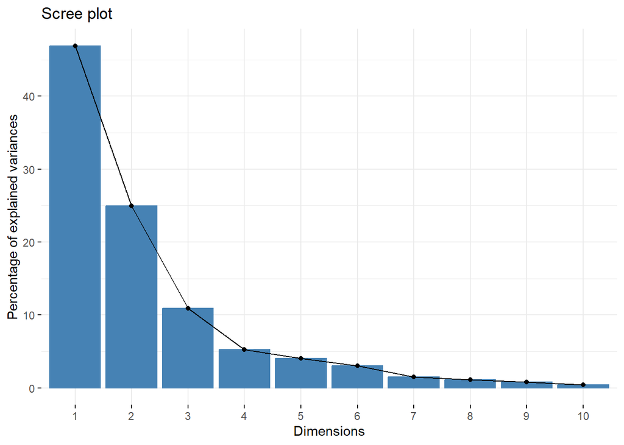

```r
fviz_eig(acp)
```

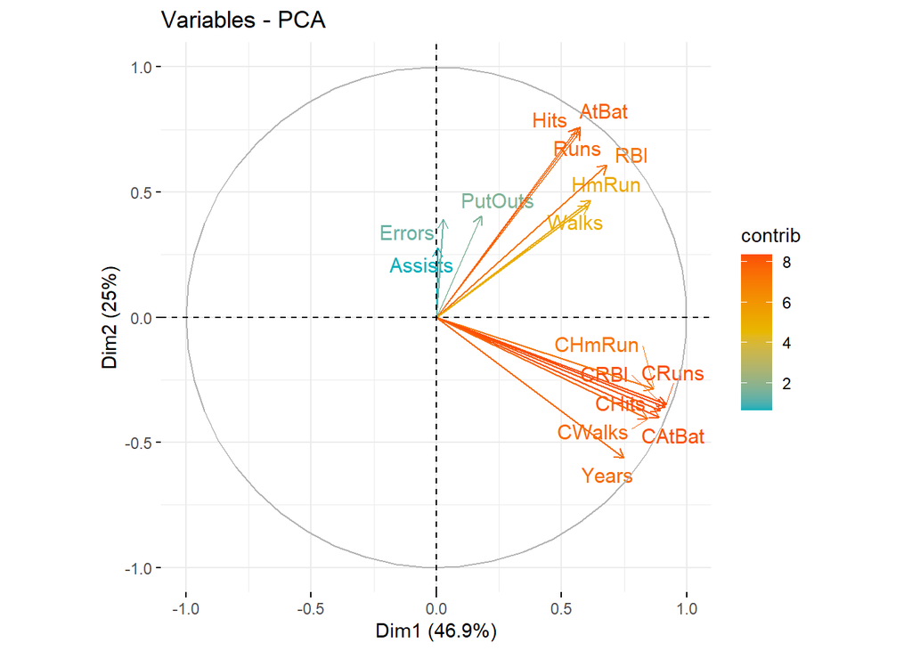

```r
fviz_pca_var(acp,
             col.var = "contrib", # Color by contributions to the PC
             gradient.cols = c("#00AFBB", "#E7B800", "#FC4E07"),
             repel = TRUE     # Avoid text overlapping
             )
```

```r
#On fait maintenant la régression -
dat.train.acp = data.frame(cbind(acp$x, Salary = dat.train$Salary))
mod.acp = lm(Salary ~ ., dat.train.acp)
eqm.lm.acp = mean( (predict(mod.acp) - dat.train$Salary)^2 )
eqm.lm.acp
```

```
## [1] 100765
```

```r
dat.test.acp = data.frame(predict(acp, newdata = dat.test[,-17]))
eqm.lm.valid.acp = mean( (predict(mod.acp, newdata=dat.test.acp) - dat.test$Salary)^2 )
eqm.lm.valid.acp
```

```
## [1] 104864.2
```

On obtient exactement les mêmes résultats!

Et si on essayait d’enlever des CP?

```r
#Disons que je prends 3 CP
mod3 = lm(Salary ~ ., dat.train.acp[,c(1:3,17)])
eqm.lm.acp3 = mean( (predict(mod3) - dat.train$Salary)^2 )
eqm.lm.acp3
```

```
## [1] 126604
```

Et si on regardait maintenant l’EQM sur le jeu de validation?

```r
#Toujours pour 3 Composantes principales
dat.test.acp = data.frame(predict(acp, newdata = dat.test))
eqm.lm.acp3.test = mean( (predict(mod3, newdata = dat.test.acp)-dat.test$Salary)^2)
eqm.lm.acp3.test
```

```
## [1] 81463.06
```

```r
#Et si on prenait juste 3 variables originales?
#Comment les choisir? Ici un exemple avec les variables les plus significatives dans la régression.
#Attention : ce n'est absolument pas garanti de choisir le meilleur modèle
mod3b = lm(Salary ~ PutOuts + AtBat + CAtBat, dat.train)

eqm.lm = mean( (predict(mod3b) - dat.train$Salary)^2 )
eqm.lm
```

```
## [1] 128111.2
```

```r
eqm.lm.valid = mean( (predict(mod3b, newdata=dat.test) - dat.test$Salary)^2 )
eqm.lm.valid
```

```
## [1] 96836.82
```